# Risk Factor Analysis

## Outcome Variable

**Outcome Variable:** whz

## Predictor Variables

**Intervention Variable:** studyid

**Adjustment Set:**

unadjusted

## Stratifying Variables

The analysis was stratified on these variable(s):

- agecat

## Data Summary

| agecat | studyid | n_cell | n | outcome_variable |
| --- | --- | --- | --- | --- |
| Birth | CMC-V-BCS-2002 | 86 | 63492 | whz |
| Birth | CMIN | 19 | 63492 | whz |
| Birth | COHORTS | 9848 | 63492 | whz |
| Birth | CONTENT | 2 | 63492 | whz |
| Birth | EE | 177 | 63492 | whz |
| Birth | GMS-Nepal | 641 | 63492 | whz |
| Birth | Guatemala BSC | 0 | 63492 | whz |
| Birth | IRC | 343 | 63492 | whz |
| Birth | JiVitA-3 | 18014 | 63492 | whz |
| Birth | JiVitA-4 | 2396 | 63492 | whz |
| Birth | Keneba | 1466 | 63492 | whz |
| Birth | LCNI-5 | 0 | 63492 | whz |
| Birth | MAL-ED | 811 | 63492 | whz |
| Birth | NIH-Birth | 575 | 63492 | whz |
| Birth | NIH-Crypto | 707 | 63492 | whz |
| Birth | PROBIT | 13817 | 63492 | whz |
| Birth | PROVIDE | 532 | 63492 | whz |
| Birth | ResPak | 38 | 63492 | whz |
| Birth | SAS-CompFeed | 1103 | 63492 | whz |
| Birth | SAS-FoodSuppl | 0 | 63492 | whz |
| Birth | TanzaniaChild2 | 0 | 63492 | whz |
| Birth | ZVITAMBO | 12917 | 63492 | whz |
| 6 months | CMC-V-BCS-2002 | 368 | 69330 | whz |
| 6 months | CMIN | 243 | 69330 | whz |
| 6 months | COHORTS | 10519 | 69330 | whz |
| 6 months | CONTENT | 215 | 69330 | whz |
| 6 months | EE | 375 | 69330 | whz |
| 6 months | GMS-Nepal | 564 | 69330 | whz |
| 6 months | Guatemala BSC | 299 | 69330 | whz |
| 6 months | IRC | 408 | 69330 | whz |
| 6 months | JiVitA-3 | 16784 | 69330 | whz |
| 6 months | JiVitA-4 | 4833 | 69330 | whz |
| 6 months | Keneba | 2089 | 69330 | whz |
| 6 months | LCNI-5 | 839 | 69330 | whz |
| 6 months | MAL-ED | 1696 | 69330 | whz |
| 6 months | NIH-Birth | 537 | 69330 | whz |
| 6 months | NIH-Crypto | 715 | 69330 | whz |
| 6 months | PROBIT | 15757 | 69330 | whz |
| 6 months | PROVIDE | 603 | 69330 | whz |
| 6 months | ResPak | 239 | 69330 | whz |
| 6 months | SAS-CompFeed | 1334 | 69330 | whz |
| 6 months | SAS-FoodSuppl | 380 | 69330 | whz |
| 6 months | TanzaniaChild2 | 2028 | 69330 | whz |
| 6 months | ZVITAMBO | 8505 | 69330 | whz |
| 24 months | CMC-V-BCS-2002 | 372 | 33711 | whz |
| 24 months | CMIN | 243 | 33711 | whz |
| 24 months | COHORTS | 8822 | 33711 | whz |
| 24 months | CONTENT | 164 | 33711 | whz |
| 24 months | EE | 168 | 33711 | whz |
| 24 months | GMS-Nepal | 487 | 33711 | whz |
| 24 months | Guatemala BSC | 0 | 33711 | whz |
| 24 months | IRC | 409 | 33711 | whz |
| 24 months | JiVitA-3 | 8603 | 33711 | whz |
| 24 months | JiVitA-4 | 4735 | 33711 | whz |
| 24 months | Keneba | 1726 | 33711 | whz |
| 24 months | LCNI-5 | 563 | 33711 | whz |
| 24 months | MAL-ED | 1489 | 33711 | whz |
| 24 months | NIH-Birth | 428 | 33711 | whz |
| 24 months | NIH-Crypto | 514 | 33711 | whz |
| 24 months | PROBIT | 3970 | 33711 | whz |
| 24 months | PROVIDE | 579 | 33711 | whz |
| 24 months | ResPak | 0 | 33711 | whz |
| 24 months | SAS-CompFeed | 0 | 33711 | whz |
| 24 months | SAS-FoodSuppl | 0 | 33711 | whz |
| 24 months | TanzaniaChild2 | 6 | 33711 | whz |
| 24 months | ZVITAMBO | 433 | 33711 | whz |

The following strata were considered:

- agecat: 24 months
- agecat: 6 months
- agecat: Birth

### Dropped Strata

Some strata were dropped due to rare outcomes:

- agecat: Birth
- agecat: 24 months

## Methods Detail

We’re interested in the causal parameters $E[Y_a]$ for all values of $a \in \mathcal{A}$. These parameters represent the mean outcome if, possibly contrary to fact, we intervened to set all units to have $A=a$. Under the randomization and positivity assumptions, these are identified by the statistical parameters $\psi_a=E_W[E_{Y|A,W}(Y|A=a,W)]$. In addition, we’re interested in the mean of $Y$, $E[Y]$ under no intervention (the observed mean). We will estimate these parameters by using SuperLearner to fit the relevant likelihood factors – $E_{Y|A,W}(Y|A=a,W)$ and $p(A=a|W)$, and then updating our likelihood fit using a joint TMLE.

For unadjusted analyses ($W=\{\}$), initial likelihoods were estimated using Lrnr_glm to estimate the simple $E(Y|A)$ and Lrnr_mean to estimate $p(A)$. For adjusted analyses, a small library containing Lrnr_glmnet, Lrnr_xgboost, and Lrnr_mean was used.

Having estimated these parameters, we will then use the delta method to estimate relative risks and attributable risks relative to a prespecified baseline level of $A$.

# Results Detail

## Results Plots

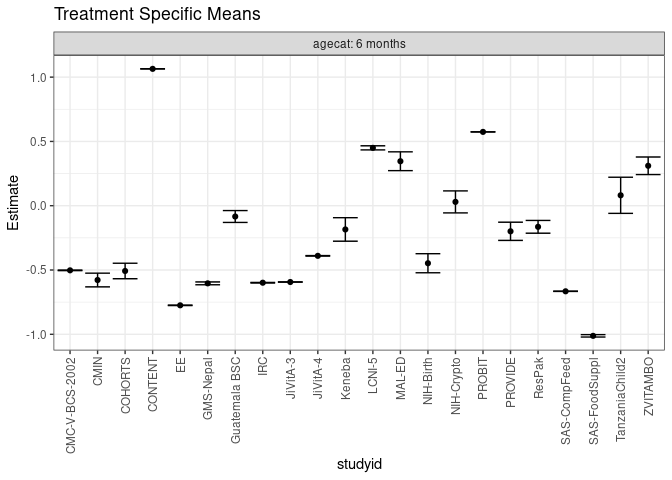

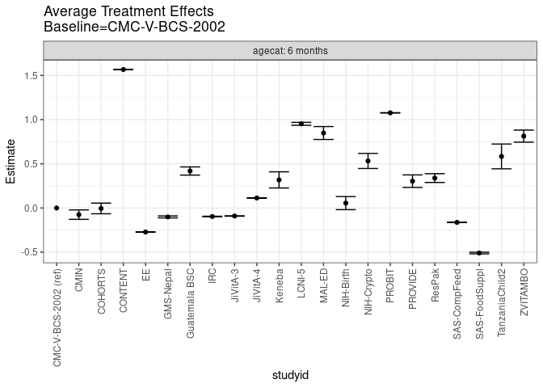

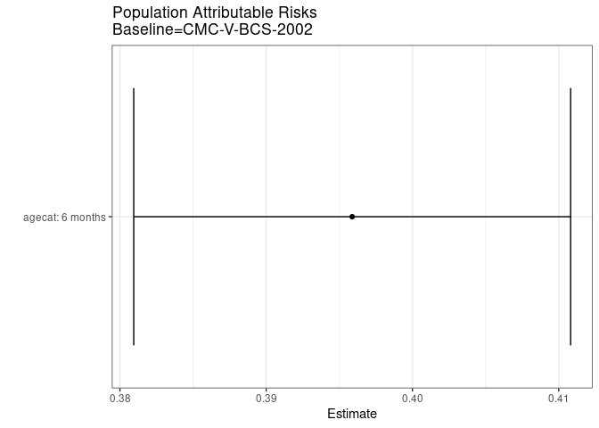

## Results Table

### Parameter: TSM

| agecat | intervention_level | baseline_level | estimate | ci_lower | ci_upper |
| --- | --- | --- | --- | --- | --- |
| 6 months | CMC-V-BCS-2002 | NA | -0.5026766 | -0.5049059 | -0.5004474 |
| 6 months | CMIN | NA | -0.5780453 | -0.6312772 | -0.5248134 |
| 6 months | COHORTS | NA | -0.5077260 | -0.5680297 | -0.4474224 |
| 6 months | CONTENT | NA | 1.0644279 | 1.0634291 | 1.0654267 |
| 6 months | EE | NA | -0.7747022 | -0.7764727 | -0.7729317 |
| 6 months | GMS-Nepal | NA | -0.6038416 | -0.6148239 | -0.5928593 |
| 6 months | Guatemala BSC | NA | -0.0840134 | -0.1301916 | -0.0378351 |
| 6 months | IRC | NA | -0.5989297 | -0.6011524 | -0.5967071 |
| 6 months | JiVitA-3 | NA | -0.5935161 | -0.5946919 | -0.5923404 |
| 6 months | JiVitA-4 | NA | -0.3898055 | -0.3918099 | -0.3878011 |
| 6 months | Keneba | NA | -0.1846038 | -0.2760585 | -0.0931490 |
| 6 months | LCNI-5 | NA | 0.4499404 | 0.4340086 | 0.4658723 |
| 6 months | MAL-ED | NA | 0.3458461 | 0.2726856 | 0.4190067 |
| 6 months | NIH-Birth | NA | -0.4474038 | -0.5215084 | -0.3732991 |
| 6 months | NIH-Crypto | NA | 0.0297622 | -0.0557753 | 0.1152998 |
| 6 months | PROBIT | NA | 0.5741099 | 0.5738264 | 0.5743935 |
| 6 months | PROVIDE | NA | -0.1990907 | -0.2698420 | -0.1283393 |
| 6 months | ResPak | NA | -0.1641841 | -0.2138301 | -0.1145381 |
| 6 months | SAS-CompFeed | NA | -0.6657084 | -0.6665005 | -0.6649163 |
| 6 months | SAS-FoodSuppl | NA | -1.0121579 | -1.0215117 | -1.0028041 |
| 6 months | TanzaniaChild2 | NA | 0.0809332 | -0.0594740 | 0.2213403 |
| 6 months | ZVITAMBO | NA | 0.3105514 | 0.2422554 | 0.3788475 |

### Parameter: E(Y)

| agecat | intervention_level | baseline_level | estimate | ci_lower | ci_upper |
| --- | --- | --- | --- | --- | --- |
| 6 months | NA | NA | -0.1067985 | -0.1215768 | -0.0920202 |

### Parameter: ATE

| agecat | intervention_level | baseline_level | estimate | ci_lower | ci_upper |
| --- | --- | --- | --- | --- | --- |
| 6 months | CMC-V-BCS-2002 | CMC-V-BCS-2002 | 0.0000000 | 0.0000000 | 0.0000000 |
| 6 months | CMIN | CMC-V-BCS-2002 | -0.0753686 | -0.1286472 | -0.0220901 |
| 6 months | COHORTS | CMC-V-BCS-2002 | -0.0050494 | -0.0653942 | 0.0552955 |
| 6 months | CONTENT | CMC-V-BCS-2002 | 1.5671045 | 1.5646286 | 1.5695804 |
| 6 months | EE | CMC-V-BCS-2002 | -0.2720256 | -0.2749695 | -0.2690817 |
| 6 months | GMS-Nepal | CMC-V-BCS-2002 | -0.1011650 | -0.1123746 | -0.0899553 |
| 6 months | Guatemala BSC | CMC-V-BCS-2002 | 0.4186633 | 0.3724312 | 0.4648953 |
| 6 months | IRC | CMC-V-BCS-2002 | -0.0962531 | -0.0993337 | -0.0931725 |
| 6 months | JiVitA-3 | CMC-V-BCS-2002 | -0.0908395 | -0.0933637 | -0.0883154 |
| 6 months | JiVitA-4 | CMC-V-BCS-2002 | 0.1128711 | 0.1098706 | 0.1158717 |
| 6 months | Keneba | CMC-V-BCS-2002 | 0.3180729 | 0.2265908 | 0.4095549 |
| 6 months | LCNI-5 | CMC-V-BCS-2002 | 0.9526170 | 0.9365467 | 0.9686874 |
| 6 months | MAL-ED | CMC-V-BCS-2002 | 0.8485227 | 0.7753186 | 0.9217269 |
| 6 months | NIH-Birth | CMC-V-BCS-2002 | 0.0552728 | -0.0188653 | 0.1294110 |
| 6 months | NIH-Crypto | CMC-V-BCS-2002 | 0.5324389 | 0.4468723 | 0.6180055 |
| 6 months | PROBIT | CMC-V-BCS-2002 | 1.0767865 | 1.0745428 | 1.0790303 |
| 6 months | PROVIDE | CMC-V-BCS-2002 | 0.3035860 | 0.2327995 | 0.3743725 |
| 6 months | ResPak | CMC-V-BCS-2002 | 0.3384925 | 0.2887965 | 0.3881886 |
| 6 months | SAS-CompFeed | CMC-V-BCS-2002 | -0.1630318 | -0.1654000 | -0.1606635 |
| 6 months | SAS-FoodSuppl | CMC-V-BCS-2002 | -0.5094813 | -0.5191124 | -0.4998502 |
| 6 months | TanzaniaChild2 | CMC-V-BCS-2002 | 0.5836098 | 0.4431850 | 0.7240347 |
| 6 months | ZVITAMBO | CMC-V-BCS-2002 | 0.8132281 | 0.7448956 | 0.8815605 |

### Parameter: PAR

| agecat | intervention_level | baseline_level | estimate | ci_lower | ci_upper |
| --- | --- | --- | --- | --- | --- |
| 6 months | CMC-V-BCS-2002 | NA | 0.3958782 | 0.3809421 | 0.4108142 |